# Continued Enrollment Increases

Despite the ever present ‘demograhic cliff in college enrollment’ that we continue to prepare for, enrollment in courses offered by the Center for Environmental Studies continues to increase.

Published

August 28, 2023

Despite the ever present threat of the *Demographic Cliff* in incoming student engagement that is proposed to be right around the corner every year by some in the academy, the [Center for Environmental Studies](https://ces.vcu.edu) continues to increase enrollment numbers.

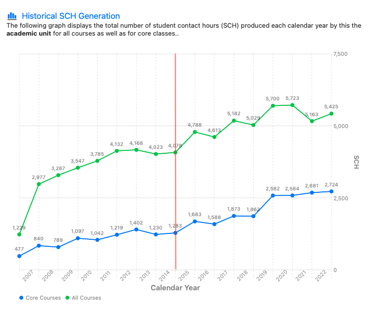

Starting in 2015, when I had the privilege of becoming the Director of Undergraduate Programs, and building momentum since 2017 when I became the Director of the Center, I’ve worked directly with the faculty and administration to take a curriculum that had sat fallow since its inception and began to modernize it.

```r
priorSCH <- c(1229,2977,3287,3547,3785,4132,4168,4023,4079)
postSCH <- c(4788,4613,5182,5029,5700,5723,5163,5425)
```